# Examining the Impacts of Natural Gas Fluctuations on Retail Electricity Costs

Author

Anand Blum, Petra Chuenarrom, Marco Da Santos Manziano, Michael Taglia

Published

November 17, 2026

# Data and Preprocessing

## Sources

All series are monthly. Prices come from the EIA Open Data API and the Henry Hub spreadsheet, and the consumer price index comes from the BLS public API. Raw pulls are cached in `data/raw/`, so the document renders without any key once those files exist. To refresh everything, delete all the files in `data/raw/` and set `EIA_API_KEY` in `.Renviron` (see `.Renviron.example`). Only the two EIA price and generation pulls need the key, since Henry Hub and the CPI are downloaded without one.

```r
library(tidyverse)
library(jsonlite)
library(plotly)
library(tseries)

# Print wide tables in full
options(width = 200, pillar.width = Inf, pillar.sigfig = 7)
```

```r
# Pull every page of an EIA API v2 route and return one data frame
get_eia <- function(route, value, facets){
  key <- Sys.getenv("EIA_API_KEY")
  stopifnot(key != "")
  base <- paste0("https://api.eia.gov/v2/", route, "/data/?api_key=", key,
                 "&frequency=monthly&data[0]=", value, facets,
                 "&sort[0][column]=period&sort[0][direction]=asc&length=5000")
  base <- gsub("\\[", "%5B", gsub("\\]", "%5D", base))
  out <- list()
  offset <- 0
  repeat{
    res <- fromJSON(paste0(base, "&offset=", offset))$response
    out[[length(out) + 1]] <- res$data
    offset <- offset + 5000
    if(offset >= as.numeric(res$total)) break
  }
  bind_rows(out)
}

# Download once, then reuse the cached CSV
cache_pull <- function(file, route, value, facets){
  path <- file.path("data/raw", file)
  if(!file.exists(path)){
    write_csv(get_eia(route, value, facets), path)
  }
  read_csv(path, show_col_types = FALSE)
}

# BLS limits each request to 10 years, so pull the CPI in three blocks
get_cpi <- function(){
  years <- list(c(2000, 2009), c(2010, 2019), c(2020, 2026))
  out <- lapply(years, function(y){
    body <- toJSON(list(seriesid = list("CUUR0000SA0"), startyear = as.character(y[1]), endyear = as.character(y[2])), auto_unbox = TRUE)
    res <- httr::POST("https://api.bls.gov/publicAPI/v1/timeseries/data/", httr::content_type_json(), body = body)
    fromJSON(httr::content(res, "text", encoding = "UTF-8"))$Results$series$data[[1]][, c("year", "period", "value")]
  })
  bind_rows(out)
}
```

```r
# Retail price in cents per kWh, by state and sector
price_raw <- cache_pull("retail_price.csv", "electricity/retail-sales", "price",
  "&facets[sectorid][]=RES&facets[sectorid][]=COM&facets[sectorid][]=IND")

# Net generation in thousand MWh, natural gas and all fuels, all sectors combined
gen_raw <- cache_pull("generation.csv", "electricity/electric-power-operational-data", "generation",
  "&facets[sectorid][]=99&facets[fueltypeid][]=NG&facets[fueltypeid][]=ALL")

# Henry Hub spot price in dollars per million BTU (EIA spreadsheet, no key needed)
hh_path <- "data/raw/RNGWHHDm.xls"
if(!file.exists(hh_path)){
  download.file("https://www.eia.gov/dnav/ng/hist_xls/RNGWHHDm.xls", hh_path, mode = "wb")
}
hh_raw <- readxl::read_excel(hh_path, sheet = "Data 1", skip = 2)

# CPI for all urban consumers, all items, not seasonally adjusted (BLS)
if(!file.exists("data/raw/cpi.csv")) write_csv(get_cpi(), "data/raw/cpi.csv")
cpi_raw <- read_csv("data/raw/cpi.csv", show_col_types = FALSE)

# Record when the data was downloaded
if(!file.exists("data/raw/download_date.txt")) writeLines(as.character(Sys.Date()), "data/raw/download_date.txt")
download_date <- readLines("data/raw/download_date.txt")

c(price = nrow(price_raw), generation = nrow(gen_raw), henry_hub = nrow(hh_raw), cpi = nrow(cpi_raw))
```

```
     price generation  henry_hub        cpi
     57288      38433        358        322
```

The data was downloaded on 2026-11-17. EIA labels its most recent months as preliminary, and they can be revised later. We keep them on purpose, since dropping them would shorten the series and shrink the holdout test.

## Clean and Join

```r
# Keep the 50 states only, drop DC, census divisions and the US total
states <- state.abb

price <- price_raw %>%
  filter(stateid %in% states) %>%
  mutate(month = as.Date(paste0(period, "-01")), price = as.numeric(price)) %>%
  select(state = stateid, month, sector = sectorid, price) %>%
  pivot_wider(names_from = sector, values_from = price, names_prefix = "price_")

gen <- gen_raw %>%
  filter(location %in% states) %>%
  mutate(month = as.Date(paste0(period, "-01")), generation = as.numeric(generation)) %>%
  select(state = location, month, fuel = fueltypeid, generation) %>%
  pivot_wider(names_from = fuel, values_from = generation, names_prefix = "gen_") %>%
  rename(gen_gas = gen_NG, gen_total = gen_ALL)

hh <- hh_raw %>%
  rename(date = 1, hh_price = 2) %>%
  mutate(month = as.Date(format(date, "%Y-%m-01"))) %>%
  select(month, hh_price)
```

### Adjust for inflation

Nominal prices rise with general inflation, and the biggest gas spikes happened in high inflation years. To keep inflation from looking like a gas effect, every price is converted to 2025 dollars using the CPI. Nominal columns are kept for a robustness check.

```r
cpi <- cpi_raw %>%
  mutate(month = as.Date(paste0(year, "-", substr(period, 2, 3), "-01")), cpi = suppressWarnings(as.numeric(value))) %>%
  select(month, cpi) %>%
  arrange(month)

# BLS did not publish October 2025 (government shutdown), so fill it by interpolation
cpi$cpi <- approx(cpi$month, cpi$cpi, xout = cpi$month)$y
cpi %>% filter(month >= "2025-09-01", month <= "2025-11-01")
```

```
# A tibble: 3 × 2
  month           cpi
  <date>        <dbl>
1 2025-09-01 324.8
2 2025-10-01 324.4666
3 2025-11-01 324.122
```

```r
# Index the CPI so the 2025 average equals 1
cpi_2025 <- mean(cpi$cpi[format(cpi$month, "%Y") == "2025"])

# Year over year percent change, used throughout
yoy <- function(x) 100 * (x / dplyr::lag(x, 12) - 1)

macro <- hh %>%
  inner_join(cpi, by = "month") %>%
  mutate(cpi_idx = cpi / cpi_2025,
         hh_real = hh_price / cpi_idx,
         hh_yoy = yoy(hh_real))
```

### Join

The sources overlap from January 2001 to August 2026, so the joined data keeps that window. The last 12 months are flagged as the test holdout.

```r
last_month <- max(price$month)
holdout_start <- seq(last_month, by = "-11 months", length.out = 2)[2]

dat <- price %>%
  inner_join(gen, by = c("state", "month")) %>%
  inner_join(macro, by = "month") %>%
  # No reported gas generation (HI, a few MT and NE months) means zero gas
  mutate(gen_gas = replace_na(gen_gas, 0),
         gas_share = gen_gas / gen_total,
         rprice_RES = price_RES / cpi_idx,
         rprice_COM = price_COM / cpi_idx,
         rprice_IND = price_IND / cpi_idx,
         holdout = month >= holdout_start) %>%
  arrange(state, month)
```

### Flag outliers

A price is flagged when it jumps by more than 20 percent in one month and then reverses by more than 20 percent the next month. Flagged values are kept. Some are real events, such as Texas during Winter Storm Uri, and removing them would remove the gas shocks we want to study. The flags are used for robustness checks.

```r
# TRUE for a one month spike that reverses the next month
flag_spike <- function(p){
  jump <- log(p / lag(p))
  nxt <- lead(jump)
  abs(jump) > 0.2 & abs(nxt) > 0.2 & sign(jump) != sign(nxt)
}

dat <- dat %>%
  group_by(state) %>%
  mutate(out_RES = flag_spike(price_RES),
         out_COM = flag_spike(price_COM),
         out_IND = flag_spike(price_IND)) %>%
  ungroup()

# Flagged months by sector
colSums(select(dat, starts_with("out_")), na.rm = TRUE)
```

```
out_RES out_COM out_IND
     20      22      44
```

## Checks

```r
# One row per state and month, 50 states, 308 months
c(rows = nrow(dat),
  states = n_distinct(dat$state),
  months = n_distinct(dat$month),
  first = as.character(min(dat$month)),
  last = as.character(max(dat$month)),
  holdout_months = n_distinct(dat$month[dat$holdout]),
  duplicates = sum(duplicated(dat[, c("state", "month")])))
```

```
          rows         states         months          first           last holdout_months     duplicates
       "15400"           "50"          "308"   "2001-01-01"   "2026-08-01"           "12"            "0"
```

```r
# Missing values by column
colSums(is.na(dat))
```

```
     state      month  price_COM  price_IND  price_RES  gen_total    gen_gas   hh_price        cpi    cpi_idx    hh_real     hh_yoy  gas_share rprice_RES rprice_COM rprice_IND    holdout    out_RES
         0          0          0          0          2          0          0          0          0          0          0          0          0          2          0          0          0          2
   out_COM    out_IND
         0          5
```

Alaska has no residential price for August and September 2016, so those two months stay missing. They only affect year over year values for those months.

```r
# Joined dataset for the rest of the project
write_csv(dat, "data/joined_monthly.csv")
```

## National Series and Train Test Split

The time series work uses the US average retail price for each sector and the Henry Hub price. The last 12 months are held out for testing, so every test and model below uses the training months only.

```r
us <- price_raw %>%
  filter(stateid == "US") %>%
  mutate(month = as.Date(paste0(period, "-01")), price = as.numeric(price)) %>%
  select(month, sector = sectorid, price) %>%
  pivot_wider(names_from = sector, values_from = price, names_prefix = "price_") %>%
  inner_join(macro, by = "month") %>%
  mutate(rprice_RES = price_RES / cpi_idx,
         rprice_COM = price_COM / cpi_idx,
         rprice_IND = price_IND / cpi_idx,
         holdout = month >= holdout_start) %>%
  arrange(month)

train <- filter(us, !holdout)

c(train_months = nrow(train), test_months = sum(us$holdout))
```

```
train_months  test_months
         296           12
```

# General EDA

All prices below are in 2025 dollars unless labeled nominal.

## Trends Over Time

```r
# Interactive plot of the three sector prices
plot_ly(train, x = ~month) %>%
  add_lines(y = ~rprice_RES, name = "Residential") %>%
  add_lines(y = ~rprice_COM, name = "Commercial") %>%
  add_lines(y = ~rprice_IND, name = "Industrial") %>%
  layout(title = "US Retail Electricity Price by Sector",
         xaxis = list(title = "Month"),
         yaxis = list(title = "Cents per kWh, 2025 dollars"))
```

[interactive chart not shown]

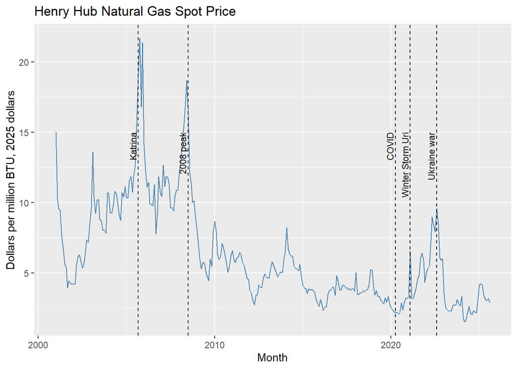

```r
# Henry Hub with real world events marked
events <- tibble(
  month = as.Date(c("2005-09-01", "2008-07-01", "2020-04-01", "2021-02-01", "2022-08-01")),
  label = c("Katrina", "2008 peak", "COVID", "Winter Storm Uri", "Ukraine war"))

ggplot(train, aes(month, hh_real)) +
  geom_line(color = "steelblue") +
  geom_vline(data = events, aes(xintercept = month), linetype = "dashed") +
  geom_text(data = events, aes(x = month, y = 15, label = label), angle = 90, vjust = -0.3, hjust = 1, size = 3) +
  labs(title = "Henry Hub Natural Gas Spot Price", x = "Month", y = "Dollars per million BTU, 2025 dollars")
```

## Nominal Versus Real

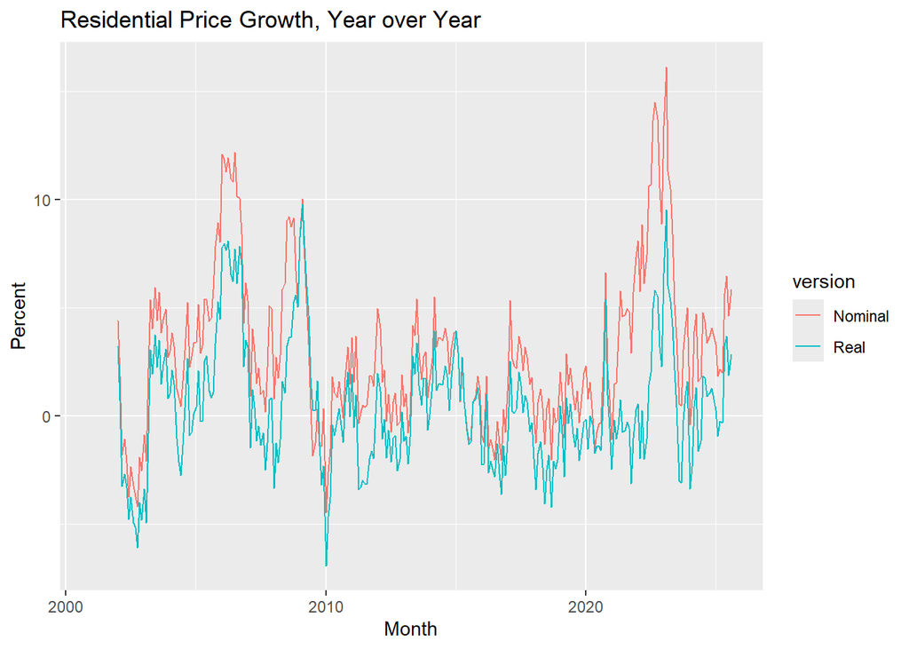

```r
# Residential year over year growth, nominal and real
train %>%
  transmute(month, Nominal = yoy(price_RES), Real = yoy(rprice_RES)) %>%
  pivot_longer(-month, names_to = "version", values_to = "growth") %>%
  ggplot(aes(month, growth, color = version)) +
  geom_line() +
  labs(title = "Residential Price Growth, Year over Year", x = "Month", y = "Percent")
```

## Seasonality

Each month’s price is divided by that year’s average price, so the trend drops out and only the calendar pattern is left.

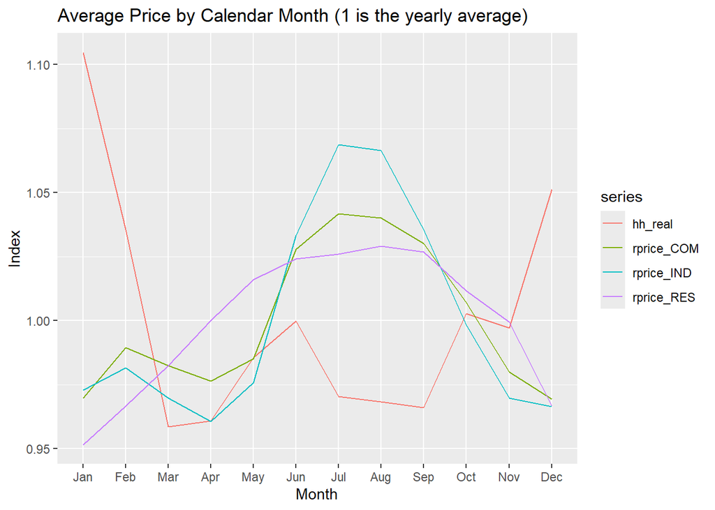

```r
season <- train %>%
  mutate(year = year(month), cal_month = month(month, label = TRUE)) %>%
  group_by(year) %>%
  mutate(across(c(rprice_RES, rprice_COM, rprice_IND, hh_real), ~ .x / mean(.x))) %>%
  ungroup() %>%
  group_by(cal_month) %>%
  summarise(across(c(rprice_RES, rprice_COM, rprice_IND, hh_real), mean)) %>%
  pivot_longer(-cal_month, names_to = "series", values_to = "index")

ggplot(season, aes(cal_month, index, color = series, group = series)) +
  geom_line() +
  labs(title = "Average Price by Calendar Month (1 is the yearly average)", x = "Month", y = "Index")
```

```r
# Peak month for each series
season %>% group_by(series) %>% slice_max(index, n = 1)
```

```
# A tibble: 4 × 3
# Groups:   series [4]
  cal_month series        index
  <ord>     <chr>         <dbl>
1 Jan       hh_real    1.104700
2 Jul       rprice_COM 1.041755
3 Jul       rprice_IND 1.068682
4 Aug       rprice_RES 1.029007
```

## Volatility

```r
# Standard deviation of year over year percent change, training months
train %>%
  summarise(across(c(hh_real, rprice_RES, rprice_COM, rprice_IND), ~ sd(yoy(.x), na.rm = TRUE)))
```

```
# A tibble: 1 × 4
   hh_real rprice_RES rprice_COM rprice_IND
     <dbl>      <dbl>      <dbl>      <dbl>
1 48.50215   2.908043   2.946512   4.834628
```

# EDA Findings

- Natural gas prices peak in winter, while electricity prices peak in summer. The proposal said gas peaks in summer, so the report should state the winter peak instead.
- Gas is far more volatile than electricity. The standard deviation of year over year change is $\approx 48.5$ percent for Henry Hub, against $\approx 2.9$ for residential and commercial prices and $\approx 4.8$ for industrial. Industrial is the most volatile electricity sector. Gas has large spikes around 2005, 2008 and 2022.
- Inflation inflates nominal electricity growth, most visibly in 2022 and 2023, when nominal growth runs well above real growth. That overlaps with the Ukraine war gas spike, which is why the tests use real prices.
- Residential prices carry a clear seasonal cycle, so we compare months with year over year change, a choice the time series section checks.

# Hypothesis Tests

## Spike Definition

A spike month is a training month where the year over year change in the real Henry Hub price is above the 90th percentile of all training months. Every other training month is a non spike month. The outcome for each month is the year over year change in the real retail price six months later, so only months with a training outcome six months ahead are used. The year over year measure and the six month horizon are chosen in advance from intuition about how gas costs reach bills, and the time series section is where we check them.

```r
# Spike threshold from training months only
spike_cut <- quantile(train$hh_yoy, 0.9, na.rm = TRUE)

# Outcome is each sector's year over year change six months ahead
h1 <- train %>%
  mutate(spike = hh_yoy > spike_cut,
         y_RES = lead(yoy(rprice_RES), 6),
         y_COM = lead(yoy(rprice_COM), 6),
         y_IND = lead(yoy(rprice_IND), 6)) %>%
  filter(!is.na(hh_yoy))

# Threshold, spike months, and how many separate runs they form
c(cutoff = spike_cut, spike_months = sum(h1$spike), runs = sum(diff(c(0, h1$spike)) == 1))
```

```
  cutoff.90% spike_months         runs
    71.13521     30.00000     13.00000
```

## H1: Do Electricity Prices Rise Faster After Gas Spikes?

$H_0: \mu_{spike} = \mu_{other}$ and $H_1: \mu_{spike} > \mu_{other}$, tested separately for each sector.

### Checking assumptions

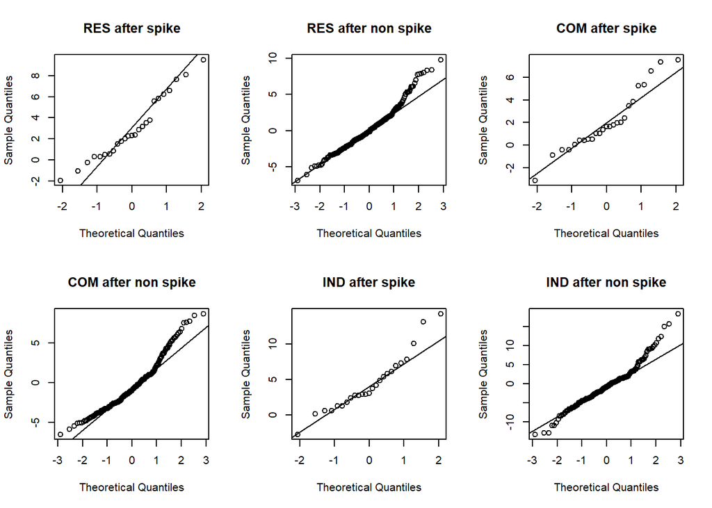

```r
# Normal QQ plots of the outcome in each group
par(mfrow = c(2, 3))
for(s in c("RES", "COM", "IND")){
  y <- h1[[paste0("y_", s)]]
  qqnorm(y[h1$spike], main = paste(s, "after spike"))
  qqline(y[h1$spike])
  qqnorm(y[!h1$spike], main = paste(s, "after non spike"))
  qqline(y[!h1$spike])
}
```

### Tests

Welch’s t-test and the Wilcoxon rank sum test assume independent observations. Spike months come in runs and the year over year windows overlap, so that assumption fails and their p values will look too strong. A moving block bootstrap resamples blocks of 12 consecutive months, which keeps that dependence, so it gives the more honest confidence interval.

```r
set.seed(123)

# Outcome and spike flag for one sector, months with an outcome only
h1_data <- function(sector){
  d <- tibble(y = h1[[paste0("y_", sector)]], spike = h1$spike)
  filter(d, !is.na(y))
}

# Moving block bootstrap of the spike minus non spike difference in means
block_boot <- function(d, block = 12, reps = 2000){
  n <- nrow(d)
  nblocks <- ceiling(n / block)
  diffs <- rep(NA, reps)
  for(i in 1:reps){
    # Stack random blocks of consecutive months, then trim to n rows
    idx <- c()
    for(b in 1:nblocks){
      start <- sample(1:(n - block + 1), 1)
      idx <- c(idx, start:(start + block - 1))
    }
    idx <- idx[1:n]
    boot <- d[idx, ]
    diffs[i] <- mean(boot$y[boot$spike]) - mean(boot$y[!boot$spike])
  }
  quantile(diffs, c(0.025, 0.975), na.rm = TRUE)
}

h1_test <- function(sector){
  d <- h1_data(sector)
  ci <- block_boot(d)
  tibble(sector = sector,
         n_spike = sum(d$spike), n_other = sum(!d$spike),
         mean_spike = mean(d$y[d$spike]), mean_other = mean(d$y[!d$spike]),
         diff = mean_spike - mean_other,
         shapiro_spike = shapiro.test(d$y[d$spike])$p.value,
         shapiro_other = shapiro.test(d$y[!d$spike])$p.value,
         welch_p = t.test(y ~ spike, data = d, alternative = "less")$p.value,
         wilcoxon_p = wilcox.test(y ~ spike, data = d, alternative = "less")$p.value,
         boot_low = ci[1], boot_high = ci[2])
}

h1_results <- bind_rows(lapply(c("RES", "COM", "IND"), h1_test))
h1_results
```

```
# A tibble: 3 × 12
  sector n_spike n_other mean_spike mean_other     diff shapiro_spike shapiro_other     welch_p  wilcoxon_p  boot_low boot_high
  <chr>    <int>   <int>      <dbl>      <dbl>    <dbl>         <dbl>         <dbl>       <dbl>       <dbl>     <dbl>     <dbl>
1 RES         25     259   2.963873  0.1836411 2.780232    0.3021635    2.052655e-5 6.570383e-5 7.036112e-6 1.001291   4.762597
2 COM         25     259   2.048305 -0.5336637 2.581969    0.09675885   2.437032e-7 3.630166e-5 3.814602e-6 0.9992847  4.500592
3 IND         25     259   4.392388 -0.6894453 5.081833    0.1139382    4.376649e-6 5.787053e-7 3.409027e-8 2.926491   7.375148
```

### Block length check

The bootstrap interval should not depend much on the block length. Here it is repeated with blocks of 6, 12 and 24 months.

```r
set.seed(123)

h1_block <- NULL
for(s in c("RES", "COM", "IND")){
  d <- h1_data(s)
  for(b in c(6, 12, 24)){
    ci <- block_boot(d, block = b)
    h1_block <- rbind(h1_block, data.frame(sector = s, block = b, low = unname(ci[1]), high = unname(ci[2])))
  }
}
h1_block
```

```
  sector block       low     high
1    RES     6 0.9560916 4.586191
2    RES    12 1.0533571 4.739994
3    RES    24 1.1431857 4.690491
4    COM     6 1.0678445 4.344536
5    COM    12 1.1142184 4.637196
6    COM    24 1.0239808 4.644302
7    IND     6 3.0457137 7.075752
8    IND    12 2.7968595 7.337515
9    IND    24 2.5855738 7.405684
```

> **Assumptions.** The spike groups are close to normal in the QQ plots, but all three non spike groups have a heavy right tail and fail the Shapiro-Wilk test, so we report the Wilcoxon rank sum test next to Welch’s t-test. The spike cutoff is $\approx 71.13521$ percent year over year growth in the real Henry Hub price. There are 30 spike months, but they form only 13 separate runs, so the effective sample is much smaller than the p values suggest.

> **Result.** We reject $H_0$ in all three sectors. Average real price growth six months after a spike is higher than after a non spike month by $\approx 2.78023$ percentage points for residential, $\approx 2.58197$ for commercial and $\approx 5.08183$ for industrial. Welch and Wilcoxon p values are all below 0.0001, and the block bootstrap 95% intervals for the difference exclude 0 in every sector. The residential and commercial lower bounds are only about 1 percentage point above 0, so those two effects are less certain than the p values alone imply. The intervals stay above 0 when the blocks are 6, 12 or 24 months long, so the result does not depend on the block length.

> **Takeaway.** Industrial prices respond most, not residential as we expected, so the residential sector having the most inelastic demand does not show up as the largest response.

# Time Series Analysis

## Series Specific EDA

### Classical Decomposition

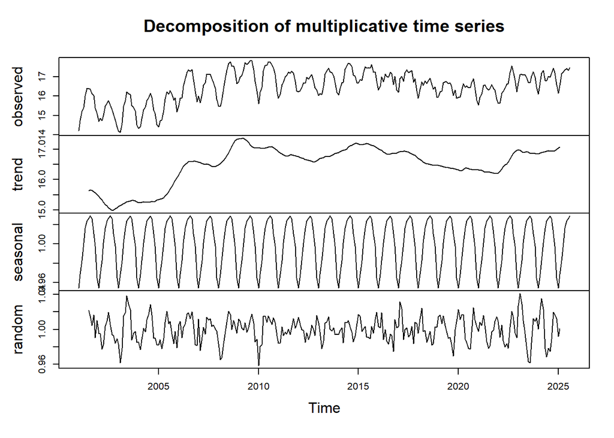

```r
res_ts <- ts(train$rprice_RES, start = c(2001, 1), frequency = 12)
hh_ts <- ts(train$hh_real, start = c(2001, 1), frequency = 12)

plot(decompose(res_ts, type = "multiplicative"))
```

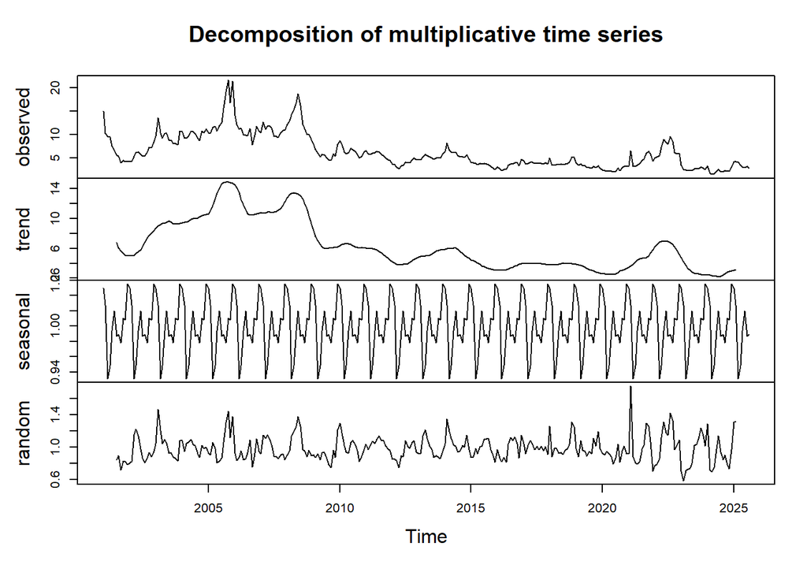

```r
plot(decompose(hh_ts, type = "multiplicative"))
```

### Autocorrelation and Lag Plots

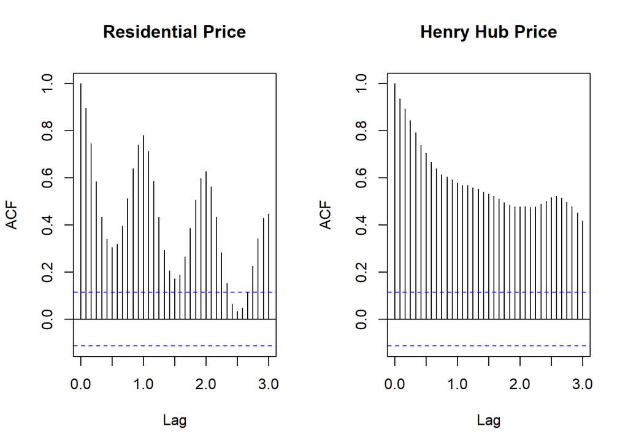

```r
par(mfrow = c(1, 2))
acf(res_ts, lag.max = 36, main = "Residential Price")
acf(hh_ts, lag.max = 36, main = "Henry Hub Price")
```

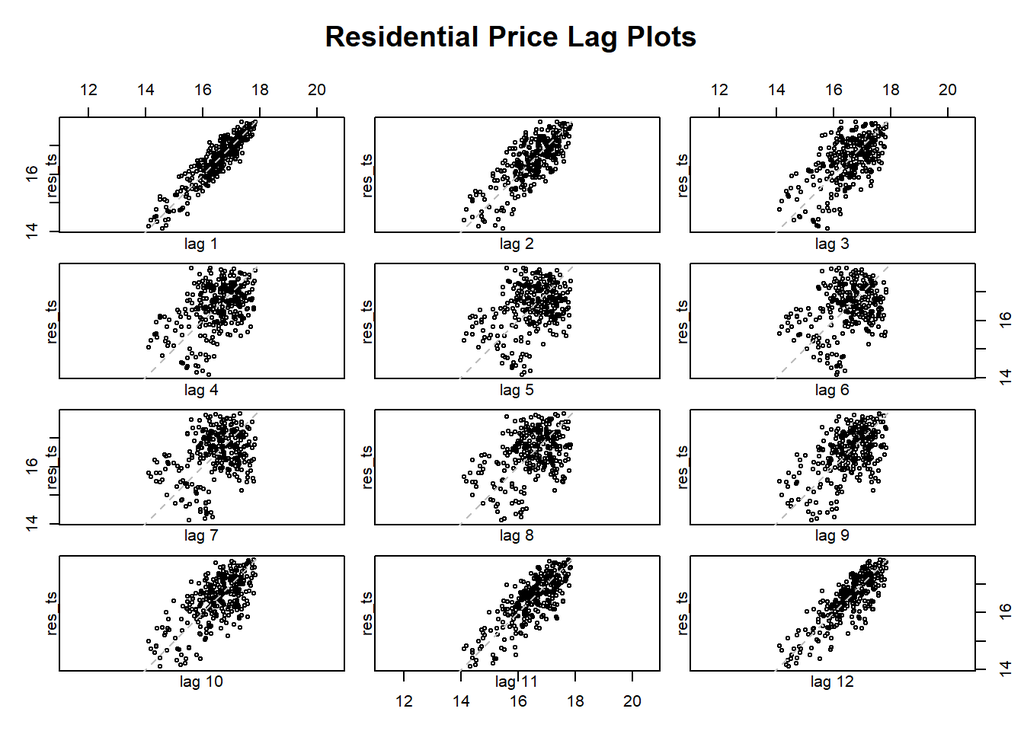

```r
lag.plot(res_ts, lags = 12, do.lines = FALSE, main = "Residential Price Lag Plots")
```

> **Reading the plots.** The residential ACF decays slowly and rises again at multiples of 12 months, and the lag plots tighten again at lag 12, so the series has a strong yearly cycle on top of its trend. The Henry Hub ACF decays slowly with no yearly cycle, which points to a persistent series that drifts.

## Stationarity Tests

The ADF test has a null of a unit root, so a small p value points to stationarity. The KPSS test reverses this, so a small p value points to non stationarity. Each series is tested in levels and as year over year percent change.

```r
series <- list(
  Residential = train$rprice_RES, Commercial = train$rprice_COM,
  Industrial = train$rprice_IND, HenryHub = train$hh_real)

test_series <- function(x){
  c(adf_p = adf.test(na.omit(x))$p.value, kpss_p = kpss.test(na.omit(x))$p.value)
}

bind_rows(
  as_tibble(t(sapply(series, test_series)), rownames = "series") %>% mutate(form = "level"),
  as_tibble(t(sapply(lapply(series, yoy), test_series)), rownames = "series") %>% mutate(form = "yoy"))
```

```
# A tibble: 8 × 4
  series           adf_p kpss_p form
  <chr>            <dbl>  <dbl> <chr>
1 Residential 0.03571504   0.01 level
2 Commercial  0.05582799   0.01 level
3 Industrial  0.04991445   0.01 level
4 HenryHub    0.02489166   0.01 level
5 Residential 0.01         0.1  yoy
6 Commercial  0.01         0.1  yoy
7 Industrial  0.01         0.1  yoy
8 HenryHub    0.01         0.1  yoy
```

> **Result.** In levels the ADF test is borderline, with p values of $\approx 0.03572$ for residential, $\approx 0.05583$ for commercial, $\approx 0.04991$ for industrial and $\approx 0.02489$ for Henry Hub, while KPSS rejects stationarity for all four (its p value is reported as 0.01, the smallest value the test prints, so the true p value is at most 0.01). In year over year form the two tests agree that all four series are stationary, with ADF p values of at most 0.01 and KPSS p values of at least 0.1. This supports the year over year change we chose in advance for the hypothesis tests.